# Statistical inference with the GSS data

## Setup

### Load packages

```r
library(ggplot2)
library(dplyr)
library(statsr)
```

### Load data

```r
load("gss.Rdata")
```

### Part 1: Data

From the wikipedian “The target population of the GSS is adults (18+) living in households in the United States. The GSS sample is drawn using an area probability design that randomly selects respondents in households across the United States to take part in the survey.” Since random sampling was used, the result can be generalized to all adults living in households in the United States.

The survey is conducted face-to-face with an in-person interview.Since we can not find the random assignment was used, we can only get the association between variables.

### Part 2: Research question

#### what’s the relation between somebody’s education level and the number of their children.

I saw some studies of the relationship between education level and number of their children from newspaper. Now I want to check whether there are indeed some difference across education level.

### Part 3: Exploratory data analysis

```r
gss <- gss %>% filter(!is.na(educ)) %>% mutate(educ_class = ifelse(educ < 12, "low", ifelse(educ > 15, "high", "middle")))
```

make a side-by-side boxplot between education class and the number of their children.

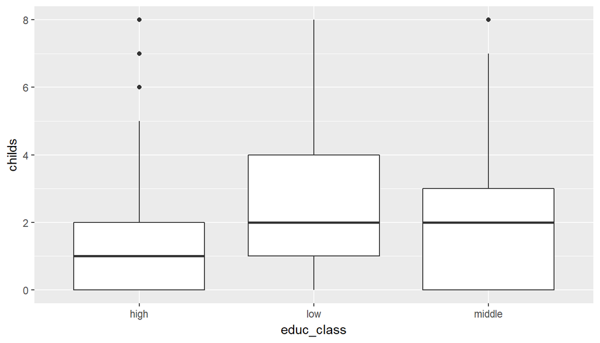

```r
gss %>% filter(!is.na(childs)) %>% ggplot(aes(x = educ_class, y = childs)) + geom_boxplot()
```

From the picture above, we can see that those who belong to high education level do have less children.

Now let’s compute the statistics across all education levels.

```r
gss %>% select("educ_class", "childs")  %>% filter(!is.na(childs)) %>% group_by(educ_class) %>% summarise(n = n(), min = min(childs),q1 = quantile(childs,0.25), median = median(childs),q3 = quantile(childs, 0.75), max = max(childs), mean = mean(childs),sd = sd(childs))
```

```
## # A tibble: 3 x 9
##   educ_class     n   min    q1 median    q3   max     mean       sd
##        <chr> <int> <dbl> <dbl>  <dbl> <dbl> <dbl>    <dbl>    <dbl>
## 1       high 12536     0     0      1     2     8 1.442964 1.481362
## 2        low 13378     0     1      2     4     8 2.658021 2.148770
## 3     middle 30828     0     0      2     3     8 1.853640 1.636151
```

## Part 4: Inference

#### Hypotheses

**H0:**The mean of the number of their children is equal across all education levels.  
**HA:**At least one pair of means is different.

#### condition

**Independence:** the data was collected by random sampling,and it’s obvious that the observations is less than 10% of all american adults.  
**Approx normal:** the data are bound below by zero,it seems to be right skewed.However,since the sample size is extreme large,the skew is acceptable.  
**Constant variance:**Base on the side-by-side box plots, the constant variance assumption appears to be reasonable.There are difference in the actual computed standard deviations, but this may due to chance.

#### method

Using anova to finish this hypotheses test.If the MSG is very larger than MSE(F-value is very large), then the diffenrence among the sample mean are not only due to chance.

Now let’s get the anova table.

```r
childs.aov <- aov(gss$childs ~ gss$educ_class)
summary(childs.aov)
```

```
##                   Df Sum Sq Mean Sq F value Pr(>F)
## gss$educ_class     2  10215    5107    1687 <2e-16 ***
## Residuals      56739 171795       3
## ---
## Signif. codes:  0 '***' 0.001 '**' 0.01 '*' 0.05 '.' 0.1 ' ' 1
## 155 observations deleted due to missingness
```

#### conclution

the p-value is approximately 0.With such small p-value, We reject H0.There are at least one pair of means is different.

To get more infomation about those difference, let’s compute a 95% confedence interval among thoes groups.

```r
TukeyHSD(childs.aov, conf.level = 0.95)
```

```
##   Tukey multiple comparisons of means
##     95% family-wise confidence level
##
## Fit: aov(formula = gss$childs ~ gss$educ_class)
##
## $`gss$educ_class`
##                   diff        lwr        upr p adj
## low-high     1.2150564  1.1643621  1.2657507     0
## middle-high  0.4106753  0.3674757  0.4538749     0
## middle-low  -0.8043811 -0.8466031 -0.7621590     0
```